# Machine Learning Weight Lifting Prediction

Darren Seaman

Sunday, May 24, 2015

### Question

Can data elements collected from accelorometers be used to predict if test subjects correctly performed barbell lifts.

### Data

Data was provided from 6 different subjects, and from from accelerometers on the belt, forearm, arm, and dumbell. Links are provided in the R code below

download the data

```r
setInternet2(use = TRUE)
fileurl = "https://d396qusza40orc.cloudfront.net/predmachlearn/pml-training.csv"
download.file(fileurl,destfile="WLE.csv")
trainstart <- read.csv("WLE.csv",header=TRUE)

##validate the data import by checking the number of rows
nrow(trainstart)
```

```
## [1] 19622
```

### Pre-processing the data

The first step is to separate the training data into to a purely training set of data and a cross validation set of data. Per lecture notes a 60% training 40% validation was chosen

```r
set.seed(1234)
trainflag <- createDataPartition(y=trainstart$classe,p=.6,list=FALSE)
traintrain <- trainstart[trainflag,]
traincv <- trainstart[-trainflag,]
dim(traintrain);dim(traincv)
names(traintrain)
head(traintrain)
str(traintrain)
summary(traintrain)
```

Reviewing the output of the above information (not shown here but can be reproduced using the .rmd file it was observed that there were many rows with almost entirely NA or blank values. At first imputing values was considered using techniques such as knnImpute but given that a majority of the values were missing or NA the columns were removed entirely.

```r
percentNAS <- sapply(traintrain,function(t) sum(is.na(t))/(sum(!is.na(t))+sum(is.na(t))))

traintrain_NONAS <- traintrain[,(percentNAS<.5)]

percentblank <- sapply(traintrain_NONAS,
                       function(b) sum((b==""))/(sum(!(b==""))+sum((b==""))))

traintidy <- traintrain_NONAS[,(percentblank<.5)]
```

The first column in the data is a row count, however because the classe outcome appears to be sorted in the input dataset this variable needed to be removed leaving it in the model resulted in rows with low row counts being assigned to classe A and high row counts to class E also dropped other variables that were deemed irrelevant such as the test subject and time stamps.

```r
dropvars <- c("cvtd_timestamp","X","user_name",
              "new_window","raw_timestamp_part_1",
              "raw_timestamp_part_2","num_window")
traintidy <-traintidy[,!(names(traintidy) %in% dropvars)]
```

take a look at a plot of the outcomes to make sure there are similar numbers for each of the outcomes

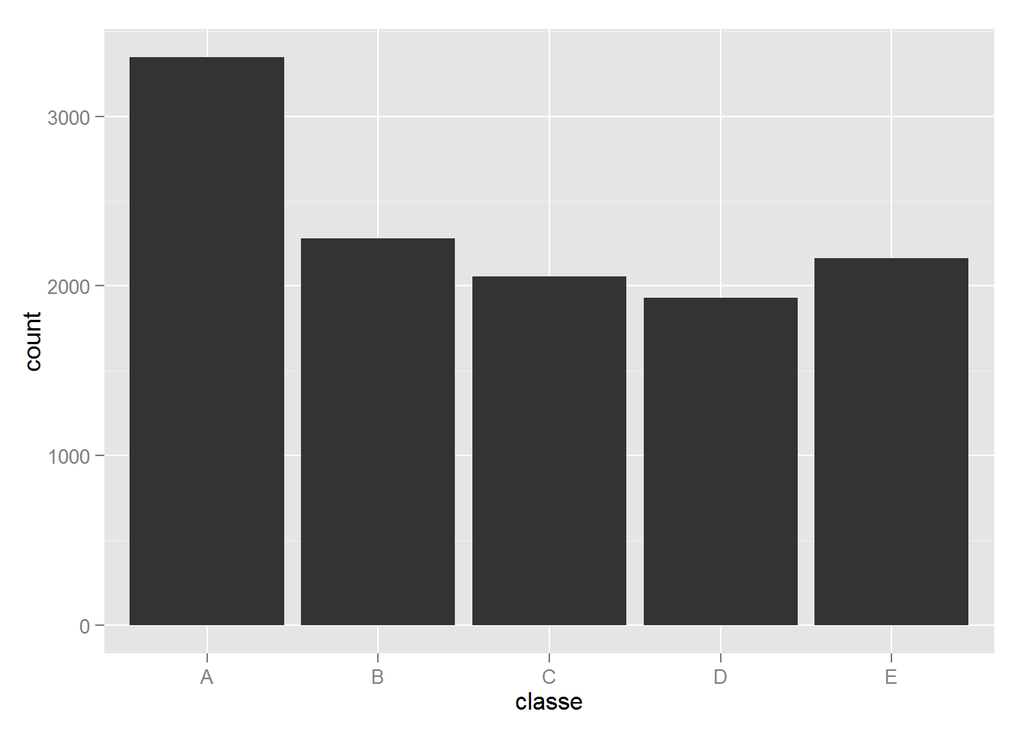

```r
qplot(classe,data=traintidy,geom="histogram")
```

check for any NA’s or missing in the remaining data and take a look at the summary information for the final training set of data

```r
NACHECK <- sapply(traintidy,function(t) sum(is.na(t)))
NACHECK
NACOLS <- traintidy[,(NACHECK > 0)]
NACOLS

BLANKCHECK <- sapply(traintidy,function(b) sum(b==""))
BLANKCHECK
BLANKCOLS <- traintidy[,(BLANKCHECK > 0)]
BLANKCOLS
```

```r
summary(traintidy)
```

```
##    roll_belt        pitch_belt          yaw_belt       total_accel_belt
##  Min.   :-28.90   Min.   :-55.8000   Min.   :-179.00   Min.   : 0.00
##  1st Qu.:  1.11   1st Qu.:  1.8275   1st Qu.: -88.30   1st Qu.: 3.00
##  Median :114.00   Median :  5.2900   Median : -12.60   Median :17.00
##  Mean   : 64.50   Mean   :  0.3029   Mean   : -11.15   Mean   :11.32
##  3rd Qu.:123.00   3rd Qu.: 15.0000   3rd Qu.:  13.10   3rd Qu.:18.00
##  Max.   :162.00   Max.   : 60.3000   Max.   : 179.00   Max.   :28.00
##   gyros_belt_x        gyros_belt_y       gyros_belt_z
##  Min.   :-1.040000   Min.   :-0.64000   Min.   :-1.4600
##  1st Qu.:-0.030000   1st Qu.: 0.00000   1st Qu.:-0.2000
##  Median : 0.030000   Median : 0.02000   Median :-0.1000
##  Mean   :-0.004883   Mean   : 0.03994   Mean   :-0.1313
##  3rd Qu.: 0.110000   3rd Qu.: 0.11000   3rd Qu.:-0.0200
##  Max.   : 2.220000   Max.   : 0.64000   Max.   : 1.6200
##   accel_belt_x      accel_belt_y     accel_belt_z     magnet_belt_x
##  Min.   :-82.000   Min.   :-69.00   Min.   :-269.00   Min.   :-49.00
##  1st Qu.:-21.000   1st Qu.:  3.00   1st Qu.:-162.00   1st Qu.:  9.00
##  Median :-15.000   Median : 35.50   Median :-152.50   Median : 34.00
##  Mean   : -5.609   Mean   : 30.21   Mean   : -72.79   Mean   : 55.34
##  3rd Qu.: -5.000   3rd Qu.: 61.00   3rd Qu.:  27.00   3rd Qu.: 59.00
##  Max.   : 85.000   Max.   :109.00   Max.   : 105.00   Max.   :485.00
##  magnet_belt_y   magnet_belt_z       roll_arm         pitch_arm
##  Min.   :360.0   Min.   :-621.0   Min.   :-180.00   Min.   :-88.800
##  1st Qu.:581.0   1st Qu.:-376.0   1st Qu.: -31.12   1st Qu.:-26.000
##  Median :601.0   Median :-320.0   Median :   0.00   Median :  0.000
##  Mean   :593.5   Mean   :-346.2   Mean   :  18.43   Mean   : -4.616
##  3rd Qu.:610.0   3rd Qu.:-306.0   3rd Qu.:  77.70   3rd Qu.: 11.300
##  Max.   :669.0   Max.   : 293.0   Max.   : 180.00   Max.   : 88.500
##     yaw_arm          total_accel_arm  gyros_arm_x        gyros_arm_y
##  Min.   :-180.0000   Min.   : 1.00   Min.   :-6.37000   Min.   :-3.440
##  1st Qu.: -43.5000   1st Qu.:17.00   1st Qu.:-1.35000   1st Qu.:-0.790
##  Median :   0.0000   Median :26.50   Median : 0.06000   Median :-0.240
##  Mean   :  -0.6392   Mean   :25.37   Mean   : 0.03313   Mean   :-0.252
##  3rd Qu.:  46.0250   3rd Qu.:32.00   3rd Qu.: 1.57000   3rd Qu.: 0.160
##  Max.   : 180.0000   Max.   :65.00   Max.   : 4.87000   Max.   : 2.840
##   gyros_arm_z       accel_arm_x       accel_arm_y       accel_arm_z
##  Min.   :-2.3300   Min.   :-404.00   Min.   :-318.00   Min.   :-630.00
##  1st Qu.:-0.0700   1st Qu.:-241.00   1st Qu.: -54.00   1st Qu.:-142.00
##  Median : 0.2300   Median : -41.00   Median :  14.00   Median : -47.00
##  Mean   : 0.2696   Mean   : -59.79   Mean   :  32.44   Mean   : -70.44
```

[output cut: 50 more lines]

```
##  Max.   :311.00000   Max.   :231.0000   Max.   : 359.00   Max.   : 923.0
##  accel_forearm_z   magnet_forearm_x  magnet_forearm_y magnet_forearm_z
##  Min.   :-446.00   Min.   :-1280.0   Min.   :-896.0   Min.   :-973
##  1st Qu.:-181.00   1st Qu.: -618.0   1st Qu.:  -1.0   1st Qu.: 185
##  Median : -36.00   Median : -387.5   Median : 587.0   Median : 507
##  Mean   : -53.56   Mean   : -313.9   Mean   : 378.7   Mean   : 391
##  3rd Qu.:  27.00   3rd Qu.:  -75.0   3rd Qu.: 736.0   3rd Qu.: 652
##  Max.   : 285.00   Max.   :  672.0   Max.   :1450.0   Max.   :1090
##  classe
##  A:3348
##  B:2279
##  C:2054
##  D:1930
##  E:2165
##
```

Other preprocessing steps were considered such as principle component anlaysis were explored, but are not included herein. Predictor standardization, box cox, and logging also didn’t seem necessary. Plots of the original predictors were also considered but not included due to the significant number of plots

### Choose the algorithm - Train the Model

Because this is a classification prediction linear models such as regression are not applicable The best approach is most likely classification trees, but rather than use just a single tree whcy not use a better and highly accurate method of random forest

```r
set.seed(1234)
modelRanForest <- randomForest(classe ~ .,n.var=25,data=traintidy,importance=TRUE)
modelRanForest
```

```
##
## Call:
##  randomForest(formula = classe ~ ., data = traintidy, n.var = 25,      importance = TRUE)
##                Type of random forest: classification
##                      Number of trees: 500
## No. of variables tried at each split: 7
##
##         OOB estimate of  error rate: 0.65%
## Confusion matrix:
##      A    B    C    D    E class.error
## A 3344    2    0    0    2 0.001194743
## B   17 2258    4    0    0 0.009214568
## C    0   19 2032    3    0 0.010710808
## D    0    0   18 1910    2 0.010362694
## E    0    0    2    8 2155 0.004618938
```

Review the Importance output (only for the top 10)

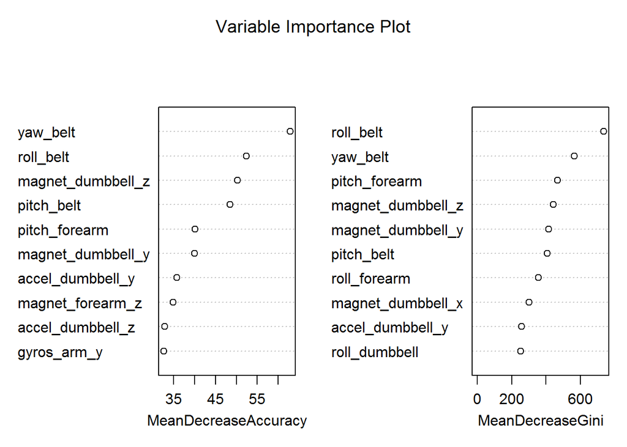

```r
varImpPlot(modelRanForest,sort=TRUE,n.var=10,main="Variable Importance Plot")
```

NOTE: Initially ran the code below as part of the caret package however it took too long so decided to use the randomForest package the results were the same.

```r
##modelRanForest <- train(classe ~ .,data = traintidy,method ='rf')
##modelRanForest
```

### Cross Validation and out of sample error rate

Theoretically speaking the out of sample error rate (generalization error) should be higher than the in sample error rate (resubstitution error). From the table output above the in sample error rate is 77 (assigned the incorrect class) out of 11,776 or 0.65% (representing an accuracy of 99.35%. To find the out of sample error rate the model can be applied to the validation set of data.

```r
pred <- predict(modelRanForest,traincv)
table(pred,traincv$classe)
```

```
##
## pred    A    B    C    D    E
##    A 2232   11    0    0    0
##    B    0 1502   13    0    0
##    C    0    5 1352   22    2
##    D    0    0    3 1262    2
##    E    0    0    0    2 1438
```

From the table above we can see the error rate is 60 out of 7,846 or 0.76% (accuracy of 99.24%) which confirms the theory above.

### Evaluation

```r
setInternet2(use = TRUE)
fileurl = "https://d396qusza40orc.cloudfront.net/predmachlearn/pml-testing.csv"
download.file(fileurl,destfile="WLE_OUTSAMPLE.csv")
teststart <- read.csv("WLE_OUTSAMPLE.csv",header=TRUE)

testpred1 <- predict(modelRanForest,teststart)
```

Results not shown here intentionally